# Answers to Questions

## Chapter 11. Growing Trees

### 1

Our function will have type *α* $→$ *α* tree $→$ **bool**. It takes a element to look for, a tree holding that kind of element, and returns `true` if the element is found, or `false` otherwise.

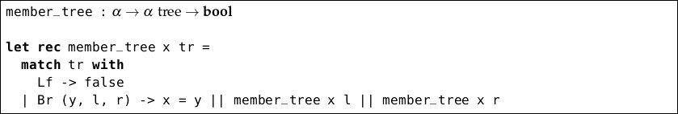

Note that we have placed the test `x = y` first of the three to ensure earliest termination upon finding an appropriate element.

### 2

Our function will have type *α* tree $→$ *α* tree. A leaf flips to a leaf. A branch has its left and right swapped, and we must recursively flip its left and right sub-trees too.

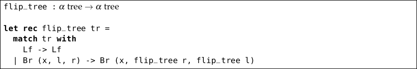

### 3

We can check each part of both trees together. Leaves are considered equal, branches are equal if their left and right sub-trees are equal.

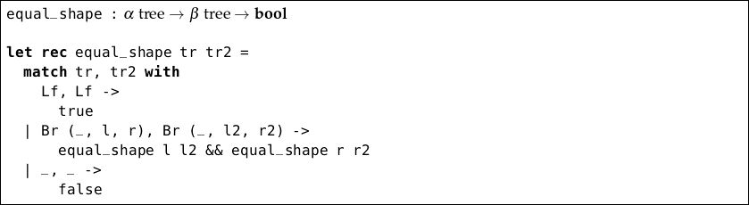

### 4

We can use the tree insertion operation repeatedly:

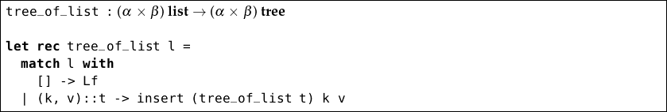

There will be no key clashes, because the argument should already be a dictionary. If it is not, earlier keys are preferred since `insert` replaces existing keys.

### 5

We can make list dictionaries from both tree dictionaries, append them, and build a new tree from the resultant list.

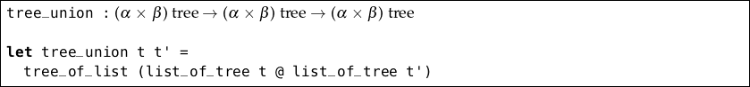

The combined list may not be a dictionary (because it may have repeated keys), but `tree_of_list` will prefer keys encountered earlier. So, we put entries from `t’` after those from `t`.

### 6

We will use a list for the sub-trees of each branch, with the empty list signifying there are no more i.e. that this is the bottom of the tree. Thus, we only need a single constructor.

**`type`**`’a mtree = Branch`**`of`**`’a * ’a mtree list`

So, now we can define `size`, `total`, and `map`.

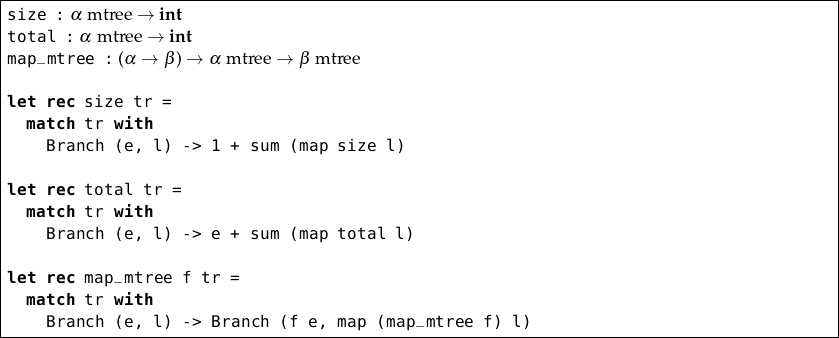

In fact, when there is only one pattern to match, we can put it directly in place of the function’s argument, simplifying these definitions:

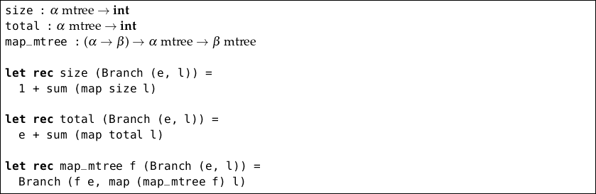

## Chapter 12. In and Out

### 1

A first attempt might be:

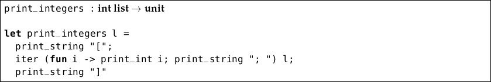

However, there are two problems:

`OCaml`  
`# [1; 2; 3];;`  
`- : int list = [1; 2; 3]`  
`# print_integers [1; 2; 3];;`  
`[1; 2; 3; ]- : unit = ()`

There is an extra space after the last element, and a semicolon too. We can fix this, at the cost of a longer program:

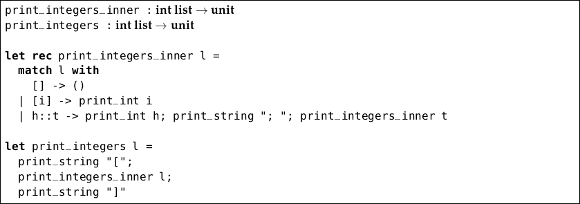

Now, the result is correct:

`OCaml`  
`# [1; 2; 3];;`  
`- : int list = [1; 2; 3]`  
`# print_integers [1; 2; 3];;`  
`[1; 2; 3]- : unit = ()`

### 2

We must deal with the exception raised when `read_int` attempts to read something which is not an integer, as before. When that exception is caught, we try again, by recursively calling ourselves. The function ends when three integers are input correctly, returning them as a tuple.

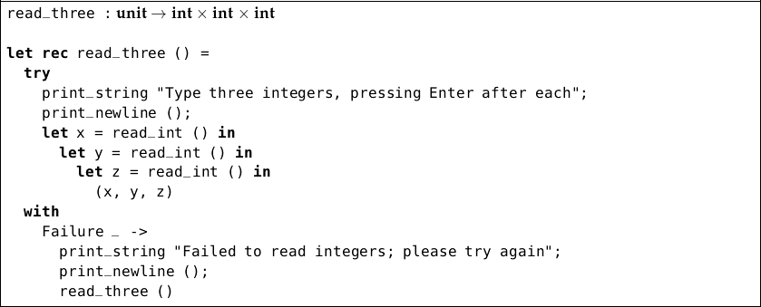

You may wonder why we used nested **`let`**`…` **`in`**`…` structures rather than just writing `(read_int (), read_int (), read_int ())` – the evaluation order of a tuple is not specified and OCaml is free to do what it wants.

### 3

We ask the user how many dictionary entries will be entered, eliminating the need for a special “I have finished” code. First, a function to read a given number of integer–string pairs, dealing with the usual problem of malformed integers:

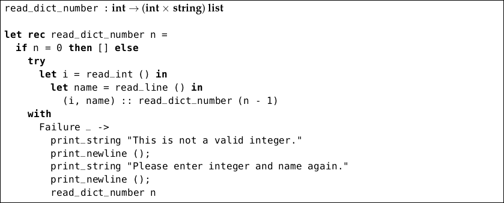

And now, asking the user how many entries there will be, and calling our first function:

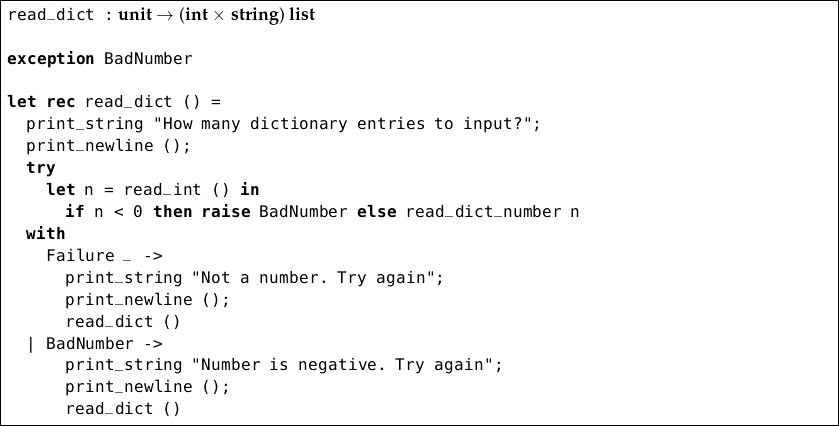

Notice that we defined, raised, and handled our own exception `BadNumber` to deal with the user asking to read a negative number of dictionary entries – this would cause `read_dict_number` to fail to return.

### 4

If we write a function to build the list of integers from $1$ to *n* (or the empty list if *n* is zero):

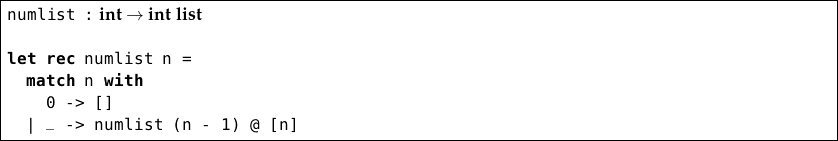

We can then write a function to output a table of a given size to an output channel.

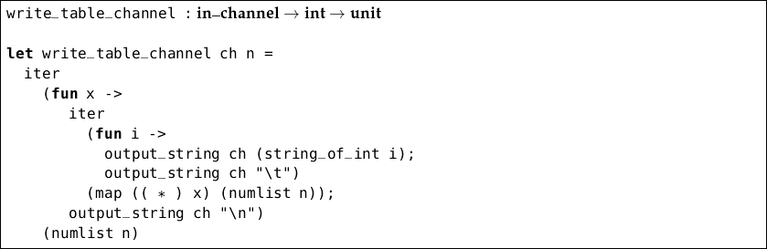

Look at this carefully. We are using nested calls to `iter` to build the two-dimensional table from one-dimensional lists. Can you separate this into more than one function? Which approach do you think is more readable?

We can test `write_table_channel` most easily by using the built-in output channel `stdout` which just writes to the screen:

`OCaml`  
`# write_table_channel stdout 5;;`  
`1 2 3 4 5`  
`2 4 6 8 10`  
`3 6 9 12 15`  
`4 8 12 16 20`  
`5 10 15 20 25`  
`- : unit = ()`

Now we just need to wrap it in a function to open an output file, write the table, and close the output, dealing with any errors which may arise.

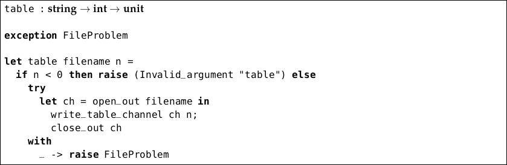

In addition to raising `Invalid_argument` in the case of a negative number, we handle all possible exceptions to do with opening, writing to, and closing the file, re-raising them as our own, predefined one. Is this good style?

### 5

We write a simple function to count the lines in a channel by taking a line, ignoring it, and adding one to the result of taking another line; our recursion ends when an `End_of_file` exception is raised – it is caught and $0$ ends the summation.

The main function `countlines` just opens the file, calls the first function, and closes the file. Any errors are caught and re-raised using the built-in `Failure` exception.

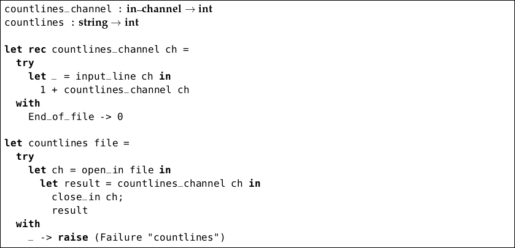

### 6

As usual, let us write a function to deal with channels, and then deal with opening and closing files afterward. Our function takes an input channel and an output channel, adds the line read from the input to the output, follows it with a newline character, and continues. It only ends when the `End_of_file` exception is raised inside `input_line` and caught.

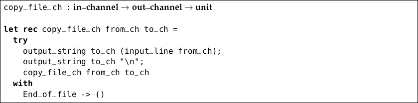

Now we wrap it up, remembering to open and close both files and deal with the many different errors which might occur.

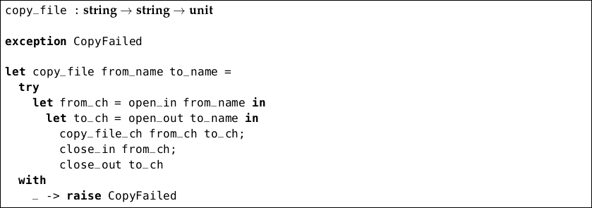

## Chapter 13. Putting Things in Boxes

### 1

Two references, `x` and `y`, of type **int ref** have been created. Their initial values are $1$ and $2$. Their final values are $2$ and $4$. The type of the expression is **int** because this is the type of `!x + !y`, and the result is $6$.

### 2

The expression `[ref 5; ref 5]` is of type **int ref list**. It contains two references each containing the integer 5. Changing the contents of one reference will not change the contents of the other. The expression **`let`**`x = ref 5`**`in`**`[x; x]` is also of type **int ref list** and also contains two references to the integer 5. However, altering one will alter the other:

`OCaml`  
`# let r = let x = ref 5 in [x; x];;`  
`val r : int ref list = [{contents = 5}; {contents = 5}]`  
`#``match r with h::_ -> h := 6;;`  
`Warning 8 [partial-match]: this pattern-matching is not exhaustive.`  
`Here is an example of a case that is not matched:`  
`[]`  
`- : unit = ()`  
`# r;;`  
`- : int ref list = [{contents = 6}; {contents = 6}]`

### 3

We can write a function `forloop` which takes a function of type **int $→$ *α*** (where alpha would normally be **unit**), together with the start and end numbers:

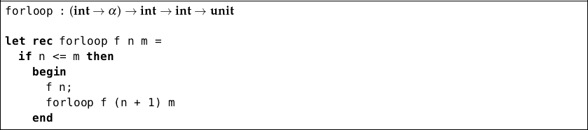

For example:

`OCaml`  
`# forloop print_int 2 10;;`  
`2345678910- : unit = ()`  
`# forloop print_int 2 2;;`  
`2- : unit = ()`

### 4

`[|1; 2; 3|]` : **int array**

`[|true; false; true|]` : **bool array**

`[|[|1|]|]` : **(int array) array** which is **int array array**

`[|[1; 2; 3]; [4; 5; 6]|]` : **int list array**

`[|1; 2; 3|].(2) <- 4` : **unit**, updates the array to `[|1; 2; 4|]`

### 5

We use a **`for`** construct:

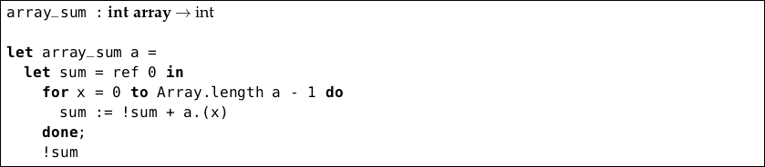

Note that this works for the empty array, because a **`for`** construct where the second number is less than the first never executes its expression.

### 6

Since we wish to reverse the array in place, our function will have type *α* array $→$ unit. Our method is to proceed from the first element to the half-way point, swapping elements from either end of the array. If the array has odd length, the middle element will not be altered.

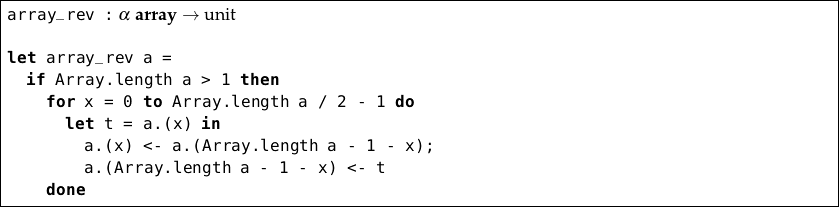

### 7

We will represent the **int array array** as an array of columns so that `a.(x).(y)` is the element in column `x` and row `y`.

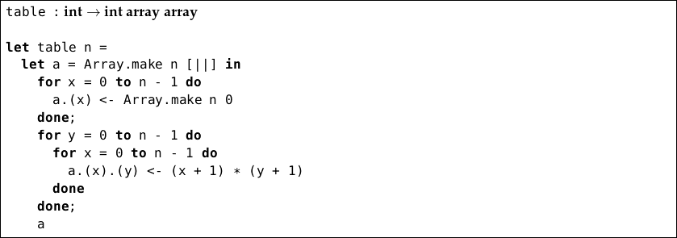

Note that the result is correct for `table 0`.